# Genotype likelihoods, priors, and their use in an ancestry HMM

- Show All Code
- Hide All Code
- View Source

Single-read calling under low coverage — where the prior lives, and what accumulation can and cannot do

Author

Fausto Rodríguez-Zapata

Published

July 16, 2026

At ~0.4× coverage the SNP50K genotype matrix looks pathological: 70% of cells are missing, of the rest **97% are hom-REF**, essentially **none are hom-ALT**, and wherever a minority (ALT) read appears the site is overwhelmingly called **heterozygous** (the depth-split below). Taken at face value that reads as a genome that is almost entirely B73 with a thin, ubiquitous sprinkle of heterozygosity — which is *not* what a BC2S3 NIL is. This note asks the two questions that pattern forces:

1. **What produced it — the reads, or the caller?** Why does a single ALT read become a HET call; when is that the right call, and when is it just the genotype prior asserting itself?
2. **Can per-site genotype confidence be recovered downstream?** Does accumulating genotype likelihoods (GLs) across a gene / haplotype stretch / fixed bin rescue the calls, or is the information simply not there?

**NoteMotivation — the pattern this note explains**

The SNP50K cohort (1,439 skim NILs, ~0.4×) was genotyped with a posterior / HWE caller (`bcftools call -mv`). Across all 1,439 × 50,995 = 73,381,805 genotype cells:

| class | count | % of all | % of called |
| --- | --- | --- | --- |
| REF-hom `0/0` | 21,168,920 | 28.85 | 97.02 |
| HET | 648,539 | 0.88 | 2.97 |
| ALT-hom | 1,001 | 0.00 | 0.00 |
| missing `./.` | 51,563,345 | 70.27 | — |

Splitting the same cells by read depth shows *why* — **at a single read, 448,805 cells are called HET but only 355 hom-ALT**, against 15.9 M REF:

| depth | REF | HET | ALT | missing |
| --- | --- | --- | --- | --- |
| 0 | 40,524 | 1 | 0 | 51,563,345 |
| 1 | 15,868,677 | 448,805 | 355 | 0 |
| 2 | 4,057,642 | 154,596 | 138 | 0 |
| 3–5 | 1,184,345 | 44,361 | 343 | 0 |
| 6–10 | 17,559 | 727 | 163 | 0 |
| >10 | 173 | 49 | 2 | 0 |

A lone ALT read is ~1,000× more likely to be called **HET** than hom-**ALT** — the *opposite* of the single-read likelihood, which favors hom-ALT 2:1 (§1). Why the prior overturns the read, and why that is a **caller choice** (bcftools/GLIMPSE vs GATK), is the subject of §2. Full counts + provenance: [snp50k-cohort-provenance](https://github.com/sawers-rellan-labs/zealtiger/blob/main/docs/snp50k-cohort-provenance.md).

**Short answer.** *(1)* The pattern is the **caller’s prior, not biology**: a MAP / HWE caller (`bcftools`, GLIMPSE, …) turns any lone minority read into a HET because the rare-allele prior overturns the 2:1 single-read likelihood for hom-ALT; GATK, being maximum-likelihood, instead scatters spurious hom-ALT. Neither is trustworthy per site at this depth. *(2)* GLs are the correct currency, and accumulation across a stretch *does* help — but only for a **shared latent state** (the ancestry of the segment), which the count-based HMM already exploits because the read counts *are* the GL’s sufficient statistic. Accumulation does **not** manufacture per-site zygosity information, and the dilution ceiling (`d ≈ 0.3`, snp50k-genotype-identifiability.md) is unchanged by moving from counts to GLs.

Notation: biallelic site, reference (B73) allele $A$, alternate (donor) allele $B$; genotypes $\{AA, AB, BB\}=\{0/0, 0/1, 1/1\}$; per-base error $\varepsilon = 10^{-Q/10}$.

## 1. The single-site genotype likelihood — identical core in GATK, ANGSD, samtools

All three tools compute the **likelihood** $P(\text{reads}\mid G)$ per genotype with the same diploid-averaging model (ANGSD calls it “the GATK/dragon model”; samtools adds a read-dependency term that vanishes at depth 1):

$$P(\text{reads}\mid G=\{A_1,A_2\}) = \prod_{i}\Big[\tfrac12 P(b_i\mid A_1) + \tfrac12 P(b_i\mid A_2)\Big],
\qquad
P(b\mid A) = \begin{cases} 1-\varepsilon & b = A\\[2pt] \varepsilon/3 & b \neq A. \end{cases}$$

Each allele of the diploid genotype contributes with weight $\tfrac12$ — this is why the heterozygote likelihood of any single read is pinned near $\tfrac12$.

### One ALT read ($b=B$, $\varepsilon=0.01$)

| genotype | likelihood $P(\text{read}\mid G)$ | value | Phred $-10\log_{10}L$ | normalized PL |
| --- | --- | --- | --- | --- |
| $AA$ | $\varepsilon/3$ | 0.0033 | 24.8 | **25** |
| $AB$ | $\tfrac12\!\cdot\!\tfrac{\varepsilon}{3} + \tfrac12(1-\varepsilon)$ | 0.498 | 3.0 | **3** |
| $BB$ | $1-\varepsilon$ | 0.99 | 0.04 | **0** |

- **PL** $= -10\log_{10} L$, normalized by subtracting the smallest so the best genotype is 0 (the GATK worked example: probabilities $100\times$ apart give PLs $20$ apart). PL is a *likelihood*, emitted under an effectively flat genotype prior — despite GATK’s docs writing “$P(\text{Genotype}\mid\text{Data})$”.
- **GQ** $=$ (2nd-smallest PL) $-$ (smallest PL), capped at 99. Here **GQ = 3**.

So *by likelihood alone*, one alt read points to **BB (homozygous-alt), GQ 3** — a $\approx 2{:}1$ call ($\tfrac{1-\varepsilon}{1/2}\approx 2 \Rightarrow 3$ PL). **That 3-PL likelihood ratio is the entire information content of one read.** No downstream step adds to it; it can only be combined with a prior or with *other sites*.

## 2. Likelihood → posterior: where the prior lives, and what swapping it does

The genotype **call** and its meaning come from the posterior

$$P(G \mid \text{reads}) \;\propto\; \underbrace{P(\text{reads}\mid G)}_{\text{GL — identical across tools}} \;\times\; \underbrace{\pi(G)}_{\text{prior — tool-specific, swappable}} .$$

Where each tool applies $\pi$:

| tool | GL stage | prior stage |
| --- | --- | --- |
| **GATK** | `HaplotypeCaller` PairHMM → PL (likelihood) | `GenotypeGVCFs` allele-freq/HWE prior (`--heterozygosity`, default $10^{-3}$); `CalculateGenotypePosteriors` for **custom** (pedigree / population-AF) priors |
| **ANGSD** | `-GL` models (GATK / samtools / SOAPsnp) → GLs, *no calling by default* | `-doPost 1` = HWE prior at estimated allele freq; `-doPost 2` = uniform |
| **bcftools** | `mpileup` (Li 2011) → GLs | `call -m` allele-freq prior with `-P` mutation-rate hyperprior |

### HWE prior at the cohort frequency → forces HET

The genotype prior is Hardy–Weinberg at the cohort alt-allele frequency $p$ (the GL-based cohort mean $\bar p = 0.015$; provenance in §2.2): $\pi(AA,AB,BB)=((1-p)^2,\,2p(1-p),\,p^2)$. Multiplying the one-read likelihoods (from §1) by this prior and normalizing, at $p=\bar p=0.015$ and $\varepsilon=0.01$:

| genotype | likelihood $P(\text{read}\mid G)$ | $L$ | HWE prior $\pi(G)$ | $\pi$ | posterior $\propto L\cdot\pi$ | $P(G\mid\text{read})$ |
| --- | --- | --- | --- | --- | --- | --- |
| $AA$ | $\varepsilon/3$ | 0.0033 | $(1-p)^2$ | 0.970 | $\tfrac{\varepsilon}{3}\cdot(1-p)^2$ | 0.178 |
| $AB$ | $\tfrac12\!\cdot\!\tfrac{\varepsilon}{3} + \tfrac12(1-\varepsilon)$ | 0.498 | $2p(1-p)$ | 0.0296 | $p(1-p)$ | **0.810** |
| $BB$ | $1-\varepsilon$ | 0.99 | $p^2$ | 0.000225 | $(1-\varepsilon)\cdot p^2$ | 0.012 |

Taking the ratio of the two non-REF rows’ posteriors ($\propto L\cdot\pi$), HET beats ALT-hom by

$$\frac{P(AB\mid\text{read})}{P(BB\mid\text{read})}
= \frac{p(1-p)}{(1-\varepsilon)\cdot p^2}
= \frac{1-p}{(1-\varepsilon)\cdot p} \approx \frac1p \approx 66 ,$$

matching the table’s $0.810/0.012 \approx 67$. The rare-allele prior overturns the $2{:}1$ likelihood — it collapses the ALT-hom posterior to ~1% and hands 81% to the heterozygote, even though the read’s *likelihood* most favored $BB$. **The call is the prior’s, not the read’s.** This is exactly the **depth-1 row of the motivating table above** — 448,805 HET vs 355 ALT calls on single reads — and the overall 97% REF / 0.00% ALT-hom pattern in the SNP50K matrix (snp50k-cohort-provenance.md).

**Posterior callers inherit this, and most assume HWE.** bcftools `call -m`, freebayes, ANGSD `-doPost`, and the imputation tools Beagle and GLIMPSE are all **posterior callers**: each weights the genotype likelihood by a prior and reports the genotype that maximizes the product, the **maximum-a-posteriori (MAP)** estimate.

$$\hat G = \arg\max_G P(G\mid\text{data}) = \arg\max_G P(\text{data}\mid G)\,\pi(G) .$$

The maximum-likelihood choice, by contrast, keeps only the likelihood $P(\text{data}\mid G)$ and drops the prior $\pi$. The prior these callers assume is almost always Hardy–Weinberg: at the estimated allele frequency for bcftools, freebayes, and ANGSD `-doPost`, and at a reference panel’s frequencies for Beagle and GLIMPSE. So at a rare site every one of them turns a lone ALT read into a HET call. The HWE prior, not the read, decides.

GATK is the exception. It does not call genotypes on the posterior: its per-sample GT is the maximum-likelihood genotype, and the heterozygosity prior only gates whether the site is variant. There a lone ALT read is called hom-ALT, not HET. The companion note [*GATK does not call genotypes on posteriors*](https://github.com/sawers-rellan-labs/zealtiger/blob/main/docs/gatk-genotype-assignment.md) explains why, and why GATK’s own heterozygote excess has a separate paralog and coverage cause.

### Breeding prior — the single-locus NIL genotype frequencies

The NIL design is *not* HWE. Selfing after backcross drives heterozygotes to homozygotes. Single-locus genotype frequencies (donor allele freq $0.125$; selfing preserves it):

| design | $f_{AA}$ (REF-hom) | $f_{AB}$ (het) | $f_{BB}$ (donor-hom) | het : donor-hom \| introgressed |
| --- | --- | --- | --- | --- |
| **BC2S2** (bulked skim) | 0.844 | 0.0625 | 0.0938 | 40 : 60 |
| **BC2S3** (nominal NIL) | 0.859 | 0.0312 | 0.1094 | 22 : 78 |

Note the sign — $f_{BB} > f_{AB}$ — by design, an introgressed locus is *more often donor-homozygous than heterozygous* (78% vs 22% for BC2S3), because selfing removes heterozygosity. (This corrects a claim in an earlier draft that the introgression is “mostly het” — the *design* expects mostly donor-hom; the callers *report* mostly het only because donor-hom is undetectable at $0.4\times$, §5.)

### Swapping the prior flips the single-read call

The same one alt read, now with the BC2S3 breeding prior (likelihood from §1 $\times$ prior, at $\varepsilon=0.01$, posterior normalized to sum to 1):

| genotype | likelihood $P(\text{read}\mid G)$ | $L$ | BC2S3 prior $\pi(G)$ | $\pi$ | posterior $\propto L\cdot\pi$ | $P(G\mid\text{read})$ |
| --- | --- | --- | --- | --- | --- | --- |
| $AA$ | $\varepsilon/3$ | 0.0033 | $f_{AA}$ | 0.859 | $\tfrac{\varepsilon}{3}\cdot f_{AA}$ | 0.023 |
| $AB$ | $\tfrac12\!\cdot\!\tfrac{\varepsilon}{3} + \tfrac12(1-\varepsilon)$ | 0.498 | $f_{AB}$ | 0.0312 | $\tfrac12 f_{AB}$ | 0.123 |
| $BB$ | $1-\varepsilon$ | 0.99 | $f_{BB}$ | 0.1094 | $(1-\varepsilon)\cdot f_{BB}$ | **0.855** |

Taking the ratio of the two non-REF rows’ posteriors, HET now loses to ALT-hom:

$$\frac{P(AB\mid\text{read})}{P(BB\mid\text{read})}
= \frac{\tfrac12 f_{AB}}{(1-\varepsilon)\cdot f_{BB}}
= \frac{0.5 \times 0.0312}{0.99 \times 0.1094} \approx 0.14
\quad\Rightarrow\quad \textbf{DONOR-HOM} \ (\approx 7{:}1),$$

matching the table’s $0.123/0.855$.

So the *identical read and likelihood* is called **HET under the HWE prior** and **DONOR-HOM under the breeding prior**. This is the crux for the “fix the prior” argument: swapping HWE → breeding frequencies is correct and worthwhile (it counteracts the coverage-induced het-bias), **but it only relabels the default — it adds no zygosity information.** The data still speaks at only $\approx 3$ PL. One read cannot resolve het from hom under *any* prior; the prior decides the tie.

### The four priors side by side — and where each allele frequency comes from

We have now seen the two extremes — the HWE-at-cohort prior forces **HET**, the BC2S3 breeding prior forces **DONOR-HOM**. Putting all four priors a real pipeline might actually use into one comparison makes the crux explicit: **two of them are HWE priors, and their allele frequencies have completely different origins.**

| # | prior (caller) | $\pi(AA, AB, BB)$ | allele-frequency source |
| --- | --- | --- | --- |
| 1 | ML flat — GATK single-sample | $(\tfrac13,\tfrac13,\tfrac13)$ | none; per-sample GT $=\arg\max$ PL |
| 2 | GATK joint — `GenotypeGVCFs` | HWE at $\hat p = 0.125$ | *theoretical* BC2S3 donor freq, $f_{BB}+f_{AB}/2$ |
| 3 | bcftools — `mpileup \\| call -m` | HWE at $p = 0.015$ | *empirical*, GL-based cohort mean |
| 4 | BC2S3 breeding design | $(0.859, 0.031, 0.109)$ | single-locus Mendelian NIL frequencies |

GATK sits in **two** rows: its per-sample GT is flat/ML (bar 1), but its **joint** step (`GenotypeGVCFs`, and `CalculateGenotypePosteriors`) applies HWE at the estimated cohort frequency (bar 2) — so joint-genotyped GATK is *not* exempt from the het-forcing prior.

#### 2.1 The theoretical frequency $\hat p = 0.125$ (GATK joint)

Bar 2 uses the frequency **implied by the BC2S3 design itself**, not measured from data: $\hat p = f_{BB} + f_{AB}/2 = 0.1094 + 0.0312/2 = 0.125$. This isolates the effect of the HWE *shape*: even when a joint caller estimates the frequency *perfectly*, HWE at $\hat p = 0.125$ gives $\pi = (0.766, 0.219, 0.016)$ — donor-hom is $\hat p^2 = 0.016$, about $14\times$ rarer than het ($2\hat p(1-\hat p)=0.219$). So the joint call on one read is **HET at 7:1**, despite the frequency being right. The joint bar is the theoretical BC2S3 expectation run through HWE.

#### 2.2 The empirical frequency $p = 0.015$ — GL-based, not a hard-call count

Bar 3 uses the **measured** genome-wide mean alt-allele frequency of the real cohort, $\bar p = 0.015$ — far below the per-locus $0.125$ because most panel sites are near-monomorphic REF across the cohort. There are two ways to obtain such a number, and they are not equivalent:

- **From genotype likelihoods (correct at low coverage).** Estimate $p$ directly from the per-sample GLs by EM (Li 2011; ANGSD `-doMaf`/`-doPost 1`; bcftools `call -m`), marginalizing over the unknown genotypes — no genotype is ever hard-called. Each sample contributes its *expected* alt dosage $0\cdot P(AA)+1\cdot P(AB)+2\cdot P(BB)$.
- **From called genotypes (circular).** Counting REF/ALT alleles in the called matrix instead re-uses calls that were themselves made under the het-forcing HWE prior: the prior inflates het, the het-inflated calls are counted to estimate $p$, and $p$ feeds the prior again.

$\bar p = 0.015$ here is the **GL-based** estimate — the posterior-caller core (bcftools/ANGSD, Li 2011 → GLs → allele-freq prior) estimates $p$ from likelihoods and then imposes HWE$(\bar p)$. The 448,805-vs-355 depth-1 table above is the *consequence* of that imposed prior, not the source of $\bar p$.

> If a local pipeline instead computed $0.015$ by counting alleles in a hard-called VCF, that would change the reading from “correct estimator, wrong HWE shape” to “circular estimate *and* wrong shape.” (`-doMaf` = GL-based; `bcftools query` on a called VCF = hard-call.)

#### 2.3 Why no single HWE frequency represents BC2S3 — and the one caller that can

BC2S3 has a **het deficit**: $f_{BB}=0.109 > f_{AB}=0.031$ (donor-hom more common than het, because selfing collapses heterozygotes). No HWE frequency reproduces that — HWE forces $f_{AB}=2p(1-p)\ge f_{BB}=p^2$ for all $p\le\tfrac23$. So GATK’s joint step and `CalculateGenotypePosteriors` (both HWE-locked) are *structurally* unable to emit the BC2S3 call, whatever frequency they estimate.

The fix is an **inbreeding** term. The inbreeding-adjusted HWE prior at frequency $p$ with coefficient $F$ is
$$\pi = \big((1-p)^2+Fp(1-p),\;\; 2p(1-p)(1-F),\;\; p^2+Fp(1-p)\big),$$
and at $p=0.125,\ F=0.857$ this is **exactly** $(0.859, 0.031, 0.109)$ — the BC2S3 vector ($F = 1 - f_{AB}/[2p(1-p)] = 0.857$). Selfing *is* inbreeding, so the design’s single-locus frequencies are the $F$-model frequencies, not an ad-hoc table.

Which callers can apply it? **GATK** (`GenotypeGVCFs`, `CalculateGenotypePosteriors`), **bcftools** (`call -m`), **freebayes**, **Beagle**, and **GLIMPSE** are all HWE-at-$p$ (i.e. $F=0$) or reference-panel priors, with no inbreeding knob — they cannot encode $f_{BB}>f_{AB}$. **ANGSD is the exception:** with a per-individual inbreeding coefficient from `ngsF` / `ngsF-HMM` / PCAngsd (Vieira et al. 2013, ref. 8), its `-doPost` computes the $F$-adjusted genotype posterior, reproducing the BC2S3 prior. (Caveat: $F$ is a genome-wide per-individual coefficient, not a per-locus segregating-introgression prior, and $p$ is still GL-estimated — but for the het-deficient *shape* it is exact.) So the breeding prior is the $F$-model prior, and ANGSD `-doPost +F` is its standard implementation.

#### The four priors on one ALT read

Posterior $\propto$ likelihood $\times$ prior, normalized. Same read, same likelihood (PL $=[25,3,0]$); only the prior changes:

| prior (caller) | $\pi(AA, AB, BB)$ | $P(AA)$ | $P(AB)$ | $P(BB)$ | call | AB : BB |
| --- | --- | --- | --- | --- | --- | --- |
| ML flat (GATK single-sample) | $(0.333, 0.333, 0.333)$ | 0.002 | 0.333 | **0.664** | donor-hom | 0.5 |
| GATK joint, HWE $\hat p=0.125$ | $(0.766, 0.219, 0.016)$ | 0.020 | **0.858** | 0.122 | het | 7.0 |
| bcftools, HWE $p=0.015$ | $(0.970, 0.030, 0.0002)$ | 0.178 | **0.809** | 0.012 | het | 65.9 |
| BC2S3 breeding | $(0.859, 0.031, 0.109)$ | 0.023 | 0.122 | **0.855** | donor-hom | 0.1 |

**Reading.** Flat (GATK single-sample) and BC2S3 call **donor-hom** on one ALT read; both HWE priors call **het** — GATK-joint (theoretical $\hat p=0.125$) at 7:1, bcftools (empirical $p=0.015$) at 66:1. The call is the prior’s, not the read’s.

And the number of ALT reads each prior needs before it will finally call donor-hom (with $r=0$ REF reads):

| prior (caller) | min ALT reads to $P(\text{donor-hom}) > 0.5$ |
| --- | --- |
| ML flat (GATK single-sample) | 1 |
| BC2S3 breeding | 1 |
| GATK joint (HWE $\hat p=0.125$) | 4 |
| bcftools (HWE $p=0.015$) | 8 |

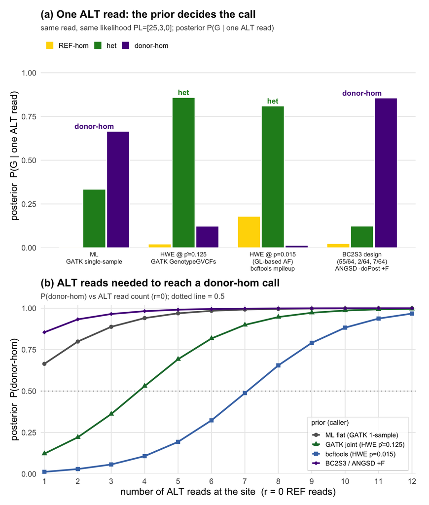

Figure 1: One ALT read under four priors. **(a)** posterior $P(G\mid\text{one ALT read})$; the winning call is labeled above each group. **(b)** ALT reads needed before each prior crosses $P(\text{donor-hom})>0.5$. Same read, same likelihood (PL $=[25,3,0]$) — the call is the prior’s. $\hat p=0.125$ is the theoretical BC2S3 donor frequency (GATK joint); $p=0.015$ is the empirical GL-based cohort mean (bcftools); BC2S3 $=$ inbreeding-HWE ($F=0.857$), applicable via ANGSD `-doPost +F`. Code: `scripts/fig_gl_prior_lowcov.R`.

```r
source(here::here("scripts/fig_gl_prior_lowcov.R"))
fig
```

## 3. From one site to a stretch: what accumulation can and cannot do

Accumulating across a gene / haplotype / bin is the right instinct. The subtlety is **what latent variable the accumulation is evidence *for*.** Two targets:

**(a) The genotype at each individual site.** Borrowing across sites requires an explicit haplotype/LD model — a reference panel (Beagle/GLIMPSE, Li–Stephens) or a founder graph (PHG). Multiplying GLs across sites of *different* genotypes is meaningless without such a model to link them. This route needs the donor founders / phased panel we lack, and teosinte’s short-range LD undercuts it.

**(b) A single latent state shared over the stretch** — the *ancestry* (REF / HET / donor-hom segment, or “which founder”). If the stretch has one state $S$, each site’s reads are a conditionally-independent emission and the product concentrates the posterior on $S$:

$$P(S \mid \text{reads}_{1:n}) \;\propto\; \pi(S)\prod_{j=1}^{n}
\underbrace{\Big[\textstyle\sum_{G} P(\text{reads}_j\mid G)\,P(G\mid S)\Big]}_{\text{emission}_j \;=\; \sum (\text{GL}) \times (\text{state-conditional genotype dist})}.$$

This is exactly RTIGER / binhmm / PHG’s `findPaths`. It works **without a panel** because the linkage is physical contiguity plus the breeding design (few recombinations) — not population LD.

### The count emission *is* the GL emission

For a biallelic site under an independent per-read error model, the pair $(n_{\text{ref}}, n_{\text{alt}})$ is the **sufficient statistic** of the per-site genotype likelihood: the emission $\sum_G P(\text{reads}_j\mid G)P(G\mid S)$ depends on the reads only through those counts. nilHMM’s count / BetaBinomial emission is a direct parameterization of this (the BetaBinomial simply adds overdispersion for mapping/paralog noise). Therefore:

> **“Use genotype likelihoods in the HMM instead of counts” is, for a biallelic site, already implemented — phrased as counts.** The caller never hard-calls per site (so it never inherits the bcftools 0%-ALT-hom prior artifact); it feeds soft per-site evidence into the along-chromosome HMM and decodes the segment.

What *full* GLs add over raw counts is real but marginal at 1 read/site: **per-base quality weighting** (down-weight low-$Q$ bases rather than counting equally) and mapping-quality / multiallelic handling. The information axis is the same: $(n_{\text{ref}}, n_{\text{alt}})$ and their qualities.

## 4. Two different HMMs — do not conflate GATK’s PairHMM

GATK’s HaplotypeCaller *does* use an HMM, but it is orthogonal to the one Ruben wants:

|  | GATK **PairHMM** | **ancestry HMM** (RTIGER / nilHMM / PHG) |
| --- | --- | --- |
| hidden path over | **bases within one read** | **marker sites along the chromosome** |
| emission | read base vs candidate haplotype (indels, base-Q) | reads at a site vs latent ancestry state |
| purpose | local re-assembly / alignment likelihood $P(\text{read}\mid\text{hap})$ | segment ancestry / genotype imputation |

GATK implements the alignment PairHMM, **not** the along-genome ancestry HMM. “They already do this” is true only for the alignment step; it is not a reusable component for ancestry segmentation. Keep the two distinct in the paper.

## 5. What survives — the information ceiling

Accumulation via the ancestry HMM buys a **confident segment state**, and the per-marker genotype is then that state **projected/imputed onto each marker** — PHG-style, and valid for GWAS/QTL (the mapping unit is the segment/dosage genotype). It is *not* an independent per-site zygosity measurement.

Three limits no GL/HMM refinement removes:

1. **The signal is compressed, not hidden by hard-calling.** Outbred-donor dilution puts the states at alt-fractions $\approx\{0,\,d/2,\,d\}=\{0,\,0.15,\,0.30\}$ with $d\approx0.3$ (empirically confirmed, snp50k-genotype-identifiability.md §2.5). GLs cannot create information the reads do not carry.
2. **Het vs donor-hom stays weak** — $0.15$ vs $0.30$ separation. A breeding prior ($f_{BB}>f_{AB}$) helps counteract the coverage het-bias, but does not resolve the zygosity.
3. **The real levers are upstream**, not in the emission: (i) **site selection** to donor-informative markers (raise $d$ toward 1, restoring $\{0,\tfrac12,1\}$ separation), (ii) **fit the emission means per taxon**, (iii) use the **BC2S2/BC2S3 prior** in place of HWE.

**Bottom line for the “GLs will rescue it” claim:** GLs are the right soft evidence and the ancestry HMM is the right accumulator — and both are essentially what the count-emission caller already does. They rescue the **segment/haplotype** call (and the imputed marker genotypes), not the isolated site, and they do not lift the dilution ceiling.

**NoteCorrections to earlier drafts of this analysis**

[output not shown]

## References

**Genotype-likelihood models and callers**

1. Li H (2011). A statistical framework for SNP calling, mutation discovery, association mapping and population genetical parameter estimation from sequencing data. *Bioinformatics* **27**(21):2987–2993. [doi:10.1093/bioinformatics/btr509](https://doi.org/10.1093/bioinformatics/btr509). — the samtools/bcftools GL model.
2. Korneliussen TS, Albrechtsen A, Nielsen R (2014). ANGSD: Analysis of Next Generation Sequencing Data. *BMC Bioinformatics* **15**:356. [doi:10.1186/s12859-014-0356-4](https://doi.org/10.1186/s12859-014-0356-4). — GL-model taxonomy + likelihood-propagation framework; software page: https://www.popgen.dk/angsd/index.php/Genotype_Likelihoods.
3. Poplin R, Ruano-Rubio V, DePristo MA, *et al.* (2017). Scaling accurate genetic variant discovery to tens of thousands of samples. *bioRxiv* 201178. [doi:10.1101/201178](https://doi.org/10.1101/201178). — GATK HaplotypeCaller.
4. DePristo MA, Banks E, Poplin R, *et al.* (2011). A framework for variation discovery and genotyping using next-generation DNA sequencing data. *Nature Genetics* **43**(5):491–498. [doi:10.1038/ng.806](https://doi.org/10.1038/ng.806). — the GATK framework; PL/GQ mechanics documented at https://gatk.broadinstitute.org/hc/en-us/articles/360035890451.

**Linkage / imputation models**

5. Li N, Stephens M (2003). Modeling linkage disequilibrium and identifying recombination hotspots using single-nucleotide polymorphism data. *Genetics* **165**(4):2213–2233. [doi:10.1093/genetics/165.4.2213](https://doi.org/10.1093/genetics/165.4.2213). — the haplotype-mosaic (Li–Stephens) model behind panel imputation (§3a).
6. Jensen SE, Charles JR, Muleta K, *et al.* (2020). A sorghum practical haplotype graph facilitates genome-wide imputation and cost-effective genomic prediction. *The Plant Genome* **13**(1):e20009. [doi:10.1002/tpg2.20009](https://doi.org/10.1002/tpg2.20009). — the founder-graph (PHG) route (§3, §5).
7. Hui R, D’Atanasio E, Cassidy LM, Scheib CL, Kivisild T (2020). Evaluating genotype imputation pipeline for ultra-low coverage ancient genomes. *Scientific Reports* **10**:18542. [doi:10.1038/s41598-020-75387-w](https://doi.org/10.1038/s41598-020-75387-w). — reference-panel imputation at ultra-low coverage (§3a).

**Inbreeding-aware genotype calling**

8. Vieira FG, Fumagalli M, Albrechtsen A, Nielsen R (2013). Estimating inbreeding coefficients from NGS data: impact on genotype calling and allele frequency estimation. *Genome Research* **23**(11):1852–1861. [doi:10.1101/gr.157388.113](https://doi.org/10.1101/gr.157388.113). — the per-individual $F$-adjusted genotype posterior (ANGSD `ngsF`, §2.3).

*Companion to snp50k-genotype-identifiability.md and snp50k-cohort-provenance.md. 2026-07-02.*